# Blog Post 3 - R Programming Reflection

# **A Reflection on Learning to Program in R**

I began this program looking forward to this class, specifically because we use R so much at work and I was excited to catch up. While certainly used for other applications, one of the most outward facing roles R plays is the creation of graphs to depict experimental results. I’ve always felt like nice look graphs could tidy up the most average results and make them present super well. GraphPad has been my primary graphing software but it doesn’t automate the way R does. That reproducibility is just unmatched compared to point and click software. Also, the control and ease of use seems better than SAS for my purposes.

Below, I’ll read in a sample cereal data set that has information about different types of cereals and their nutrition content and health rating. I’ll demonstrate making some scatter plots to investigate the relationship between certain nutrients and the cereals health rating. I’ll plot a nice looking plot for the first protein plot then mess with controlling some ggplot features just to have fun and make a cooloer looking plot for sugars.

```r
library(tidyverse)

#Read in data
cerealdata <- read.csv("/Users/EvanBrown/Desktop/ST558/cereal.csv")

#Inspect data
head(cerealdata)
```

```
##                        name mfr type calories protein fat sodium fiber carbo
## 1                 100% Bran   N    C       70       4   1    130  10.0   5.0
## 2         100% Natural Bran   Q    C      120       3   5     15   2.0   8.0
## 3                  All-Bran   K    C       70       4   1    260   9.0   7.0
## 4 All-Bran with Extra Fiber   K    C       50       4   0    140  14.0   8.0
## 5            Almond Delight   R    C      110       2   2    200   1.0  14.0
## 6   Apple Cinnamon Cheerios   G    C      110       2   2    180   1.5  10.5
##   sugars potass vitamins shelf weight cups   rating
## 1      6    280       25     3      1 0.33 68.40297
## 2      8    135        0     3      1 1.00 33.98368
## 3      5    320       25     3      1 0.33 59.42551
## 4      0    330       25     3      1 0.50 93.70491
## 5      8     -1       25     3      1 0.75 34.38484
## 6     10     70       25     1      1 0.75 29.50954
```

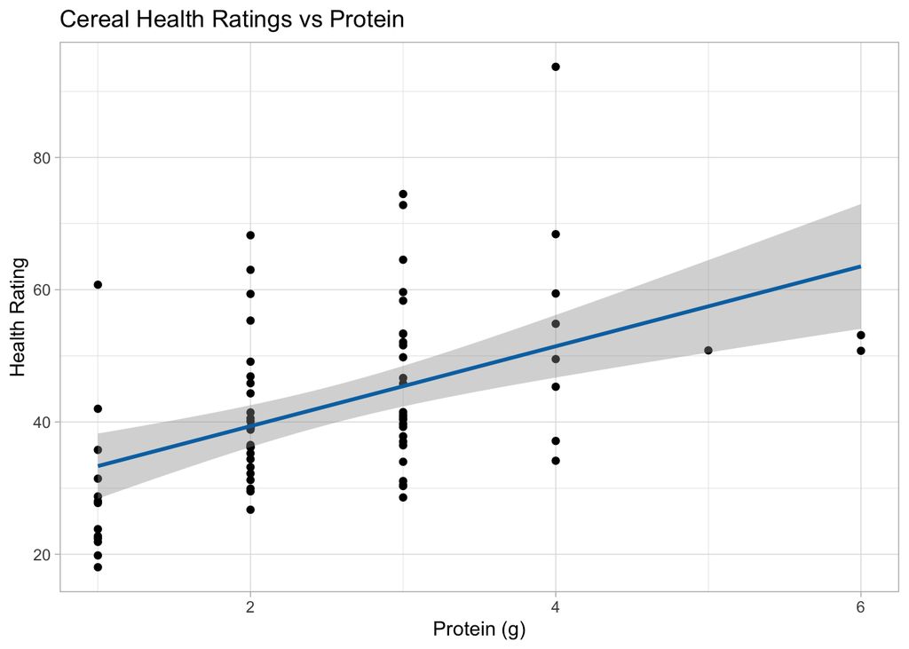

```r
#Investigate relationship between grams of protein as a predictor and rating as a response by plotting a scatter plot
proteinplot <- ggplot(cerealdata, aes(x=protein, y=rating)) +
  geom_point() + geom_smooth(method = lm, color = "#0072B2") + #Setting custom line color
  theme_light() + #Set to light theme
  labs(x = "Protein (g)", y = "Health Rating") +
  ggtitle("Cereal Health Ratings vs Protein") #Controlling title differently

#Display plot
proteinplot
```

That makes sense, more protein correlates to a higher health rating.

Now, I’ll mess around with controlling some features just to show some changes that are possible while looking at sugars data.

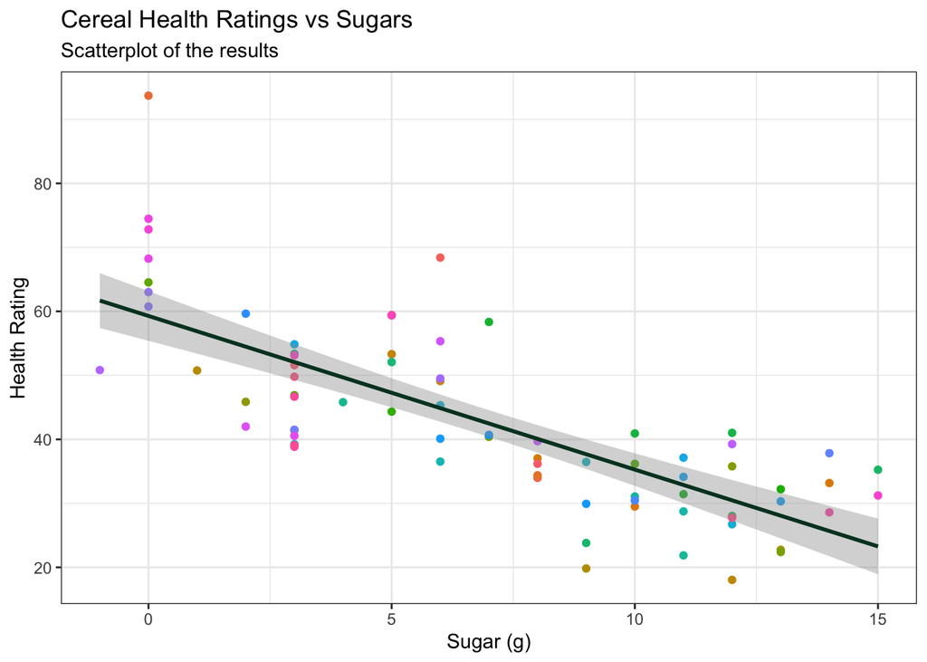

```r
#Investigate relationship between grams of sugar as a predictor and rating as a response by plotting a scatter plot
sugarplot <- ggplot(cerealdata, aes(x=sugars, y=rating)) +
  geom_point(aes(color = name)) + geom_smooth(method = lm, color = "#013f28") + #Setting custom line color, point colors to cereal name
  theme_bw() + #Set to black and white theme
  theme(legend.position="none") + #Removing legend
  labs(x = "Sugar (g)", y = "Health Rating", title = "Cereal Health Ratings vs Sugars",
       subtitle = "Scatterplot of the results") #Controlling labels and titles


#Display plot
sugarplot
```

Well that makes sense too, health rating goes down as sugar goes up!

In summary, my favorite part about R programming thus far is the ability to make figure quality, reproducible graphs. On top of that, the control we have in ggplot is unmatched compared to point and clicks like excel, graphpad, etc. I have already made good use of these techniques at work and look forward to presenting more of these graphs in a paper I’m publishing later this summer and at presentations following that.